# Swiss TPH Quarto training

📙 Getting started

Authors

Affiliation

Hélène Langet

Swiss TPH Research-IT

Zhihan Zhu

Swiss TPH Research-IT

Published

November 6, 2024

## 1 🎯 Learning objectives

1. Create a Quarto document
2. Setup the R environment to be able to use and render Quarto documents
3. Edit Quarto documents
4. Render Quarto documents in different formats

## 2 Create a new Quarto document

Quarto documents can be created and edited in RStudio.

In RStudio, you can create a new Quarto document by selecting

> **File** > **New File** > **Quarto Document…**

[figure not shown]

When you create a new Quarto document, RStudio tries to be helpful by allowing you to select a template which explains the different section of an Quarto document. R Studio will enable you select options to pick from to generate a template Quarto document to start from.

The title and the author names are not important at this stage. If the output document type you want is not one of these, do not worry - you can just pick any one and change it manually later.

Let us select **HTML** to create an html document.

Click on **Create** to open up a new Quarto (`.Qmd`) document.

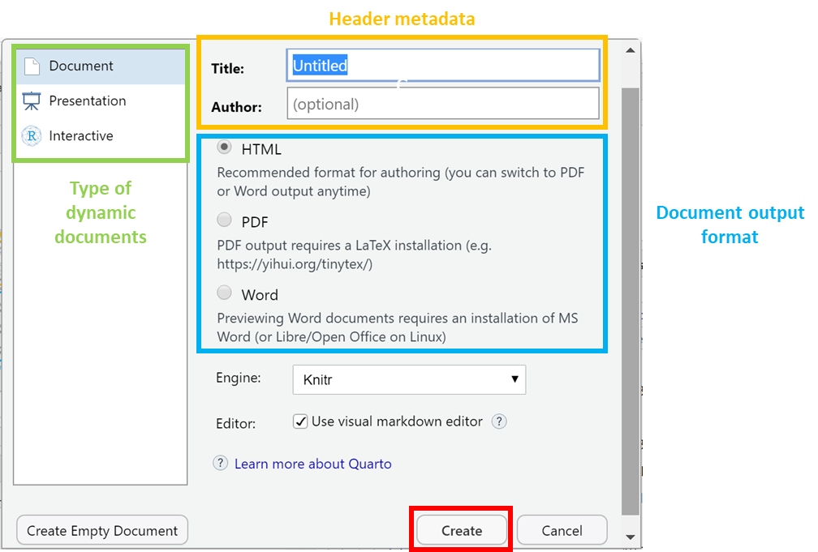

## 3 Setup your R environment

You need to ensure required packages are available

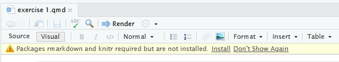

## 4 Exploring the structure of the Quarto document

There are three basic components to a Quarto document.

**Header**

At the top of the Quarto document, you will see something that looks as follows:

```
---
title: "Untitled"
format: html
---
```

This section is called the **YAML header** and it contains commands and metadata about the Quarto document. There is only one unique header in a Quarto document and it is always surrounded by `---` lines on the top and bottom of the section.

YAML is a data format that has the form of a **key: value pairing** to store data. The keys in this case are *title* and *format*. The values are those that follow the key (e.g., “Untitled” for title). These key data are used to store the settings that Quarto will use to render the output document. The keys listed above are some of many settings that Quarto has available to use.

**Markdown text**

In white background areas, any text will appear as regular text in the final report. This is actually a markup language, which can have formatting such as headings, italics, bold, numbers, and bullets.

**Code**

Code chunks, typically shown within gray backgrounds, execute commands in Quarto. In the example provided, R code is being run within these chunks. These commands may handle data processing, cleaning, or the generation of visual outputs that are integrated into the final document.

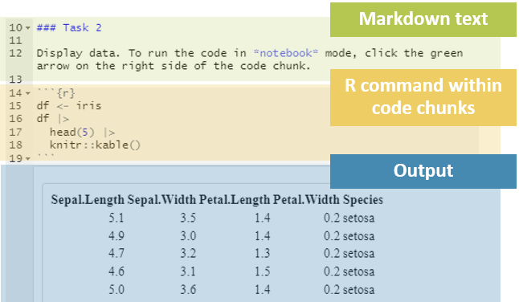

## 5 Editing text

**Useful resources**

- [Quarto Documentation - Visual Editing in RStudio](https://quarto.org/docs/visual-editor/)
- [Quarto Documentation - Markdown Basics](https://quarto.org/docs/authoring/markdown-basics.html)

The **RStudio visual editor** is a relatively new feature designed to improve the editing experience by providing an intuitive interface. In the Visual Editor, you can preview your document in a format that closely resembles its final rendered appearance, similar to working in a “*What You See Is What You Get*” (WYSIWYG) languages, such as Microsoft Word, allowing for seamless content creation and editing.

This contrasts with the **RStudio source editor**, where content is written in **Markdown** syntax. The ability to switch between these two modes allows for flexibility, depending on your preference or task.

Below is an example of the same file viewed in both the source Editor and the visual Editor:

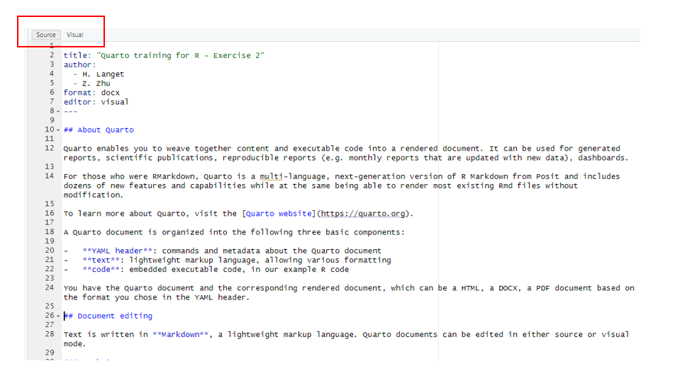

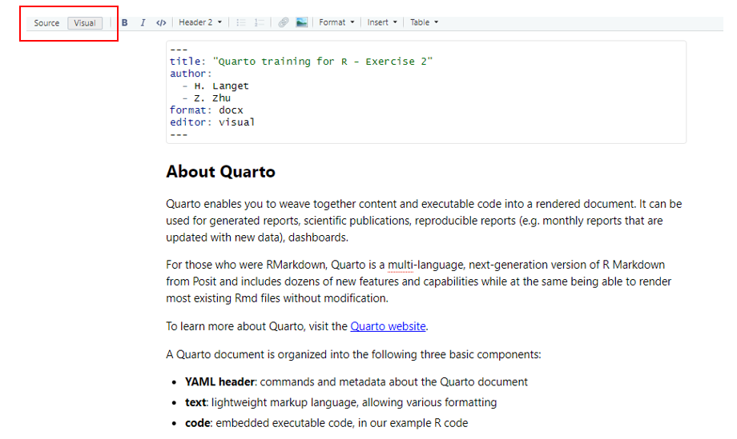

## 6 Running R code in notebook mode

To write and execute code in Quarto, you will use **code chunks**.

**Multilanguage**

As the number of programming languages used for scientific discourse is very broad, Quarto was developed to be multilingual, beginning with R, Python, Observable JavaScript (OJS), and Julia, building on the RStudio (R) and Jupyter (Python, Julia) ecosystems which are very popular among data scientists. Stata is not a language supported by Quarto.

You can run **R code** in your Quarto document, by writing R commands within **code chunks** as is displayed below

````markdown
```{r}
1 + 1
```
````

```
[1] 2
```

### 6.1 Create code chunks

**Tip**

Here are some tips for creating code chunks in RStudio

- **Backticks**: use three backticks to start and end a code chunk.
- **Toolbar icon**: you can also start a code chunk by clicking the appropriate icon in the toolbar.

[figure not shown]

- **Keyboard shortcut**: for a quicker method, use the keyboard shortcut `Ctrl` + `Alt` + `I`

### 6.2 Tables

Displaying data can be achieved with simple commands. For instance, to show the first 10 rows of the `iris` dataset, one can use:

````markdown
```{r}
iris |>
  head(10)
```
````

```
   Sepal.Length Sepal.Width Petal.Length Petal.Width Species
1           5.1         3.5          1.4         0.2  setosa
2           4.9         3.0          1.4         0.2  setosa
3           4.7         3.2          1.3         0.2  setosa
4           4.6         3.1          1.5         0.2  setosa
5           5.0         3.6          1.4         0.2  setosa
6           5.4         3.9          1.7         0.4  setosa
7           4.6         3.4          1.4         0.3  setosa
8           5.0         3.4          1.5         0.2  setosa
9           4.4         2.9          1.4         0.2  setosa
10          4.9         3.1          1.5         0.1  setosa
```

To improve the readability of tables, the `knitr::kable()` function provides a more structured and formatted output:

````markdown
```{r}
iris |>
  head(10)  |>
  knitr::kable()
```
````

| Sepal.Length | Sepal.Width | Petal.Length | Petal.Width | Species |
| --- | --- | --- | --- | --- |
| 5.1 | 3.5 | 1.4 | 0.2 | setosa |
| 4.9 | 3.0 | 1.4 | 0.2 | setosa |
| 4.7 | 3.2 | 1.3 | 0.2 | setosa |
| 4.6 | 3.1 | 1.5 | 0.2 | setosa |
| 5.0 | 3.6 | 1.4 | 0.2 | setosa |
| 5.4 | 3.9 | 1.7 | 0.4 | setosa |
| 4.6 | 3.4 | 1.4 | 0.3 | setosa |
| 5.0 | 3.4 | 1.5 | 0.2 | setosa |
| 4.4 | 2.9 | 1.4 | 0.2 | setosa |
| 4.9 | 3.1 | 1.5 | 0.1 | setosa |

**Tip**

Additional R packages can be used for more advanced and aesthetically refined tables.

## 7 Rendering

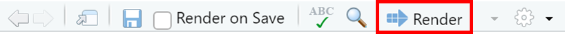

In the case of this YAML header, the Quarto document will generate an HTML file because of the `format: html` setting.

**Code errors**

If you attempt to render the document with code chunks that contain errors, the rendering process will fail. Therefore, it is essential to ensure that all code chunks run successfully in sequence before rendering the document.

### 7.1 Options

You can add options to **a specific code chunk** as is shown below:

````markdown
```{r}
#| echo: false
2 * 2
```
````

The `echo: false` option hides the code chunk in the rendered output document (only code output is displayed). In this example, rendered output document will only print:

```
[1] 4
```

Additionally, you can apply such options **globally** by specifying them in the YAML header, which configures settings for the entire Quarto document.

```
---
title: "Quarto training for R - Exercise 2"
author: Unknown author
format: html
editor: visual
echo: false
---
```

**Important**

It is important to note that the YAML header is indentation-sensitive and relies on proper whitespace formatting.

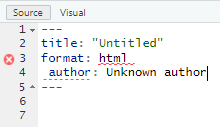

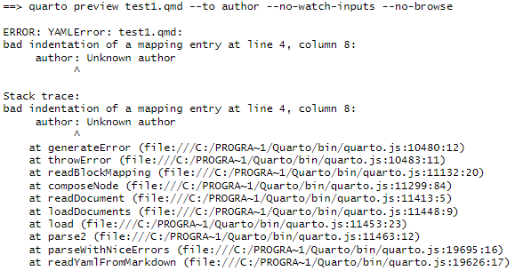

Here you may want to edit the title of your document.

### 7.2 MS Word outputs

You can also render a MS Word document by modifying the global format option in the YAML header to `format: docx`

```
---
title: "Quarto training for R - Exercise 2"
author: Unknown author
format: docx
editor: visual
---
```

### 7.3 PDF outputs

You can also render a PDF document by modifying the global format option in the YAML header to `format: pdf`

```
---
title: "Quarto training for R - Exercise 2"
author: Unknown author
format: pdf
editor: visual
---
```

While PDF documents are also able to be created, they require installing LaTeX, which can sometimes be complicated to install. `TinyTeX` is a custom LaTeX distribution that is easy to install with R. It is needed to compile R Markdown or Quarto documents to PDF.

Install the `TinyTeX` package:

````markdown
```{r}
install.packages("tinytex")
```
````

To install `TinyTeX` from the `tinytex` package, please run the R commands as follow:

````markdown
```{r}
tinytex::install_tinytex()
```
````

If specific LaTeX packages (e.g., `fancyhdr`, `lastpage`, `babel`, `tocbibind`, `worldflags`) or styles are missing, they can be installed using the following commands:

````markdown
```{r}
tinytex::tlmgr_install("fancyhdr")
```
````

````markdown
```{r}
tinytex::parse_install(
    text = "! LaTeX Error: File `ulem.sty' not found."
)
```
````

In order to avoid the warning *No hyphenation patterns were preloaded for the language French into the format.*, please consider installing the package `hyphen-french`

````markdown
```{r}
tinytex::tlmgr_install("hyphen-french")
```
````

### 7.4 Execute R code within the text

Inline code allows you to execute code within markdown, e.g. to automatically use the most up-to-date computations in narrative. Quarto provides an inline code syntax that works across all three engines (Jupyter, Knitr and OJS).

The syntax for inline code is similar to code blocks, except you use a single tick (`) rather than triple ticks (```), and you can use it in the middle of markdown. Here is an example storing the variable in a code block and then print it in a sentence using inline code:

````markdown
```{r}
comment <- "AWESOME"
```
````

You can print the sentence like this:

```
This lecture is `{r} comment`!
```

The result of the commented code is the following output:

`This lecture is AWESOME!`

Inline expressions are always evaluated when rendering and previewing `.qmd` files.

- Chunk Execution Order: Run code chunks in the correct order to avoid errors due to missing objects or incomplete definitions. Use clear and consistent chunk labels for cross-referencing.

## 8 References

- [The Epidemiologist R Handbook](https://epirhandbook.com)
- [Analytically reproducible documents](https://r-cubed-v2.rostools.org/reproducible-documents)